# factor_analysis

20191775 SoyeonLee

2021 11 14

## Ch 3: 요인분석/요인분석

### 요인분석 패키지

- R

| 방법 | R함수 |
| --- | --- |
| 주성분추출 | psych::principal(r, nfactors, rotate=‘varimax’, method=‘reg’, ..) |
| 주요인추출, ML, WLS | psych::fa(r, nfactors, rotate=‘oblimin’, fm=‘minres,pa,ml,..’, ..) |
| 주요인추출, ML | stats::factanal(x, factors, data, scores=‘none,reg,Bartlett’, rotate=‘varimax’,..) |
| factorextra | fviz_famd(mixed data), fviz_hmfa(hier multiple factor). FactoMineR 연동 |
| FactoMineR | FAMD, HMFA, MFA, PCA, MCA, … |

### 자료읽기

임산부들의 속옷에 대한 불만사항을 파악하기 위해 서울 소재 두 병원의 산부인과 외래환자 130명을 대상으로 설문조사를 실시하였다.

- 출처: 송문섭, 조신섭
- n=130(결측 포함), 모든 문항은 5점 척도(1=매우 그렇다, .., 5: 매우 그렇지 않다)

| 문항 | 질문 |
| --- | --- |
| 1. | 치수가 잘 안맞는다 |
| 2. | 컵이 작다 |
| 3. | 컵아래(밑가슴)부분이 조인다 |
| 4. | 겨드랑이 밑이 조인다 |
| 5. | 원단의 신축성이 없다 |
| 6. | 촉감이 거칠다 |
| 7. | 땀을 잘 흡수하지 못한다 |
| 8. | 오래 착용시 답답하다 |
| 9, | 착용시 앞중심 부분이 들뜬다 |
| 10, | 컵아래 부분이 위로 올라간다 |
| 11. | 어깨끈이 흘러 내린다 |
| 12. | 뒤여밈때문에 착용시 불편하다 |
| 13. | 앞여밈때문에 착용시 불편하다 |
| 14. | 가슴을 잘 받쳐주지 못한다 |
| 15. | 가슴을 잘 모아주지 못한다 |
| 16. | 가슴의 흔들림을 잘 고정시키지 못한다 |
| 17. | 디자인이 세련되지 못한다 |
| 18, | 디자인이 다양하지 못하다 |

```r
op <- par(no.readonly = TRUE)
library(knitr)
library(tidyverse)
# 변수 정리
underwear <- read.csv('C:/Users/foxgi/OneDrive/project/DWU/multivariate/linear_algebra/data/QUSTNAIR.csv', header = TRUE)
dim(underwear)
```

```
## [1] 130  18
```

### 자료정리

- 결측이 있는 관측값을 제거하여 X에 저장하시오 (결측 제거후 관측값이 몇개인지 확인할 것).

```r
X <- na.omit(underwear)
dim(X)
```

```
## [1] 101  18
```

```r
head(X)
```

```
##   Q01 Q02 Q03 Q04 Q05 Q06 Q07 Q08 Q09 Q10 Q11 Q12 Q13 Q14 Q15 Q16 Q17 Q18
## 1   2   2   2   4   4   4   3   3   2   3   4   4   4   4   3   4   2   1
## 2   2   5   2   4   4   5   4   2   4   2   4   4   4   4   4   4   5   1
## 3   3   2   2   3   2   3   2   2   4   4   3   3   3   3   3   3   3   3
## 5   2   2   4   4   3   4   4   2   4   2   4   4   4   4   4   4   3   4
## 6   2   2   1   3   4   4   4   3   3   2   4   2   2   1   3   3   4   4
## 7   2   2   2   3   3   4   4   4   4   3   2   3   4   2   2   3   4   3
```

### 자료탐색/요인분석 적절성

- X의 상관행렬을 시각화하시오

```r
R <- cor(X)

knitr::kable(R, digits=3)
```

|  | Q01 | Q02 | Q03 | Q04 | Q05 | Q06 | Q07 | Q08 | Q09 | Q10 | Q11 | Q12 | Q13 | Q14 | Q15 | Q16 | Q17 | Q18 |
| --- | --- | --- | --- | --- | --- | --- | --- | --- | --- | --- | --- | --- | --- | --- | --- | --- | --- | --- |
| Q01 | 1.000 | 0.472 | 0.356 | 0.082 | 0.112 | 0.191 | 0.183 | 0.302 | 0.148 | 0.011 | -0.027 | -0.010 | 0.246 | 0.236 | 0.237 | 0.124 | 0.135 | 0.165 |
| Q02 | 0.472 | 1.000 | 0.244 | 0.127 | 0.059 | 0.062 | 0.086 | 0.127 | 0.111 | -0.022 | -0.114 | 0.021 | 0.139 | 0.138 | 0.045 | 0.071 | 0.113 | 0.131 |
| Q03 | 0.356 | 0.244 | 1.000 | 0.317 | 0.229 | 0.176 | 0.066 | 0.272 | 0.148 | -0.050 | 0.088 | 0.223 | 0.373 | 0.235 | 0.254 | 0.114 | 0.292 | 0.203 |
| Q04 | 0.082 | 0.127 | 0.317 | 1.000 | 0.119 | 0.213 | 0.150 | 0.270 | 0.167 | 0.191 | 0.100 | 0.331 | 0.288 | 0.034 | 0.054 | 0.166 | 0.127 | 0.070 |
| Q05 | 0.112 | 0.059 | 0.229 | 0.119 | 1.000 | 0.408 | 0.171 | 0.338 | 0.114 | 0.074 | 0.093 | 0.234 | 0.169 | 0.007 | 0.002 | -0.047 | 0.118 | 0.063 |
| Q06 | 0.191 | 0.062 | 0.176 | 0.213 | 0.408 | 1.000 | 0.416 | 0.329 | 0.138 | 0.052 | 0.028 | 0.245 | 0.109 | 0.207 | 0.253 | 0.191 | 0.126 | 0.048 |
| Q07 | 0.183 | 0.086 | 0.066 | 0.150 | 0.171 | 0.416 | 1.000 | 0.217 | 0.144 | 0.153 | 0.218 | 0.102 | 0.265 | 0.250 | 0.248 | 0.234 | 0.032 | -0.089 |
| Q08 | 0.302 | 0.127 | 0.272 | 0.270 | 0.338 | 0.329 | 0.217 | 1.000 | 0.217 | 0.153 | 0.131 | 0.324 | 0.118 | 0.180 | 0.117 | -0.067 | 0.322 | 0.298 |
| Q09 | 0.148 | 0.111 | 0.148 | 0.167 | 0.114 | 0.138 | 0.144 | 0.217 | 1.000 | 0.286 | 0.248 | 0.431 | 0.262 | 0.188 | 0.076 | 0.192 | 0.322 | 0.149 |
| Q10 | 0.011 | -0.022 | -0.050 | 0.191 | 0.074 | 0.052 | 0.153 | 0.153 | 0.286 | 1.000 | 0.297 | 0.305 | 0.291 | 0.180 | 0.124 | 0.291 | -0.039 | -0.005 |
| Q11 | -0.027 | -0.114 | 0.088 | 0.100 | 0.093 | 0.028 | 0.218 | 0.131 | 0.248 | 0.297 | 1.000 | 0.380 | 0.353 | 0.164 | 0.174 | 0.115 | 0.063 | -0.002 |
| Q12 | -0.010 | 0.021 | 0.223 | 0.331 | 0.234 | 0.245 | 0.102 | 0.324 | 0.431 | 0.305 | 0.380 | 1.000 | 0.364 | 0.090 | 0.110 | 0.224 | 0.205 | 0.133 |
| Q13 | 0.246 | 0.139 | 0.373 | 0.288 | 0.169 | 0.109 | 0.265 | 0.118 | 0.262 | 0.291 | 0.353 | 0.364 | 1.000 | 0.208 | 0.118 | 0.168 | 0.056 | -0.006 |
| Q14 | 0.236 | 0.138 | 0.235 | 0.034 | 0.007 | 0.207 | 0.250 | 0.180 | 0.188 | 0.180 | 0.164 | 0.090 | 0.208 | 1.000 | 0.633 | 0.424 | 0.143 | 0.066 |
| Q15 | 0.237 | 0.045 | 0.254 | 0.054 | 0.002 | 0.253 | 0.248 | 0.117 | 0.076 | 0.124 | 0.174 | 0.110 | 0.118 | 0.633 | 1.000 | 0.541 | 0.135 | 0.003 |
| Q16 | 0.124 | 0.071 | 0.114 | 0.166 | -0.047 | 0.191 | 0.234 | -0.067 | 0.192 | 0.291 | 0.115 | 0.224 | 0.168 | 0.424 | 0.541 | 1.000 | 0.142 | 0.015 |
| Q17 | 0.135 | 0.113 | 0.292 | 0.127 | 0.118 | 0.126 | 0.032 | 0.322 | 0.322 | -0.039 | 0.063 | 0.205 | 0.056 | 0.143 | 0.135 | 0.142 | 1.000 | 0.625 |
| Q18 | 0.165 | 0.131 | 0.203 | 0.070 | 0.063 | 0.048 | -0.089 | 0.298 | 0.149 | -0.005 | -0.002 | 0.133 | -0.006 | 0.066 | 0.003 | 0.015 | 0.625 | 1.000 |

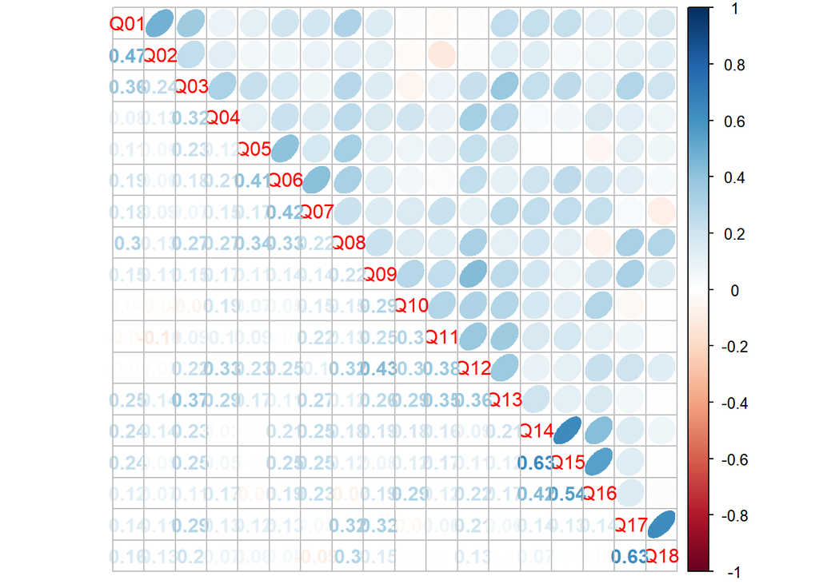

```r
## 상관행렬 시각화
library(corrplot)
corrplot.mixed(R, upper='ellipse')
```

- KMO의 MSA를 구하고 요인분석을 진행해도 되는지 설명하시오

```r
## KMO의 MSA: 상관관계(행렬)기 요인분석을 하기에 적합한지 측정
library(psych)
KMO(R)
```

```
## Kaiser-Meyer-Olkin factor adequacy
## Call: KMO(r = R)
## Overall MSA =  0.7
## MSA for each item =
##  Q01  Q02  Q03  Q04  Q05  Q06  Q07  Q08  Q09  Q10  Q11  Q12  Q13  Q14  Q15  Q16
## 0.65 0.65 0.76 0.75 0.72 0.71 0.71 0.69 0.75 0.69 0.73 0.72 0.72 0.74 0.67 0.68
##  Q17  Q18
## 0.63 0.61
```

MSA가 0.7이 나왔고 이는 평범한 수준으므로, 요인분석을 계속해도 됩니다.

- Bartlett의 구형성검정(H0: Rho = I )을 하고 요인분석을 진행해도 되는지 설명하시오